# COVIDMINDER Bootcamp Notebook

Alex Chan

5/05/2020

# 1 Final Project: Submission Links

*This should be the first section of your final project notebook. Fill out the following according to how you submitted your notebook!*

- github repository: https://github.com/TheRensselaerIDEA/COVID-Notebooks (for reference)
- My github ID: *alexchan18*
- github issues addressed by this work: `#27`
- Github branch name of my submitted notebook: *feature-27*
- link to merged notebook (post these to LMS!:
  - https://github.com/TheRensselaerIDEA/COVID-Notebooks/blob/feature-27/MATP-4400-FINAL/covid-notebook-Chana6.Rmd
  - https://github.com/TheRensselaerIDEA/COVID-Notebooks/blob/feature-27/MATP-4400-FINAL/covid-notebook-Chana6.pdf

# 2 Overview & Problems Tackled

*On March 11, 2020, the World Health Organization declared COVID-19 a global pandemic. The number of cases reached a point where the entire world needed to take action. In the United States, state governors began closing down states to reduce the rate of infection. This meant that all citizens had to remain in their homes until further notice. Fast forward 6 weeks, the citizens of the United States are eager to leave their homes and return to normal life. The decision to do open up the country will be made based on the rate of infection and the increase in new cases. I looked at the data for this in New York State to see if Governor Cuomo should make the decision to open.*

*The first problem was visualizing the number of new deaths per day.*

*The second problem was visualizing the number of deaths per 100k.*

# 3 Data Description

*I used the data for every county in the United States that was updated daily*

*From this large dataset, I extracted the data for every county in New York State*

*Then, I had to extract the FIPS code, confirmed cases, and deaths for each county and store this information in a data frame because the other information was not of use.*

# 4 Results

## 4.1 Problem 1

We need to visualize the number of new deaths per days in New York, separated by counties. The graph will be represented 5 times, every 3 days since April 23rd.

### 4.1.1 Methods

Take country data for April 23rd, April 26, April 29th, May 2nd, and May 5th. Extract data for only New York counties. Create graphs from data frames created through extraction. Then, find difference in number of deaths between days to determine number of new deaths per day.

For each day:

1. Read in dataset for desired date
2. Extract data for all rows with New York as state
3. Extract FIPS code, number of confirmed cases, and number of deaths for each county
4. Remove NULL rows from data frame
5. Determine number of new deaths by subtracting cumulative deaths of old day from new day

The Following 5 graphs show the number new deaths in each county north of Weschester

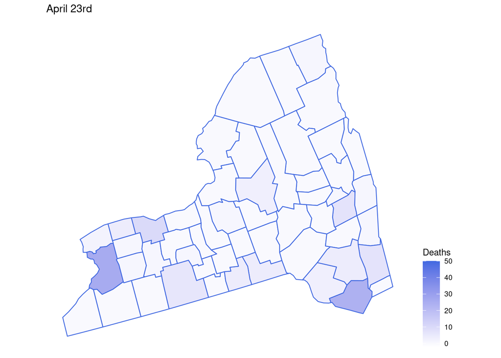

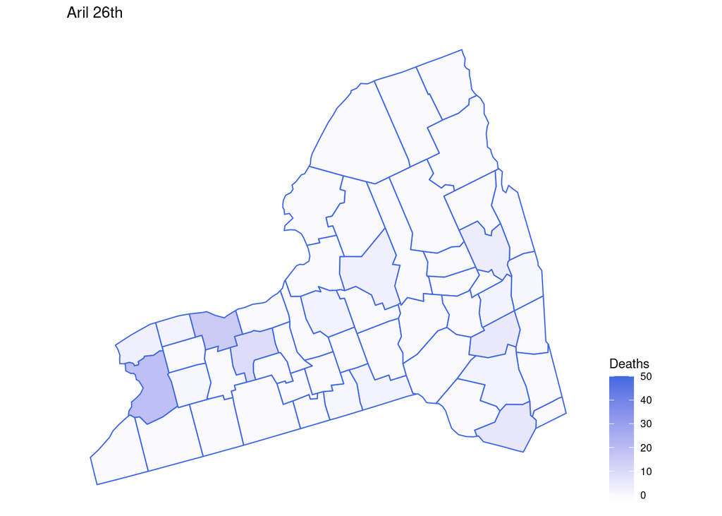

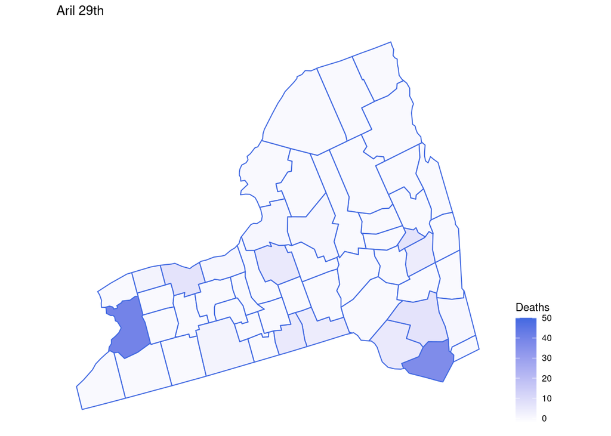

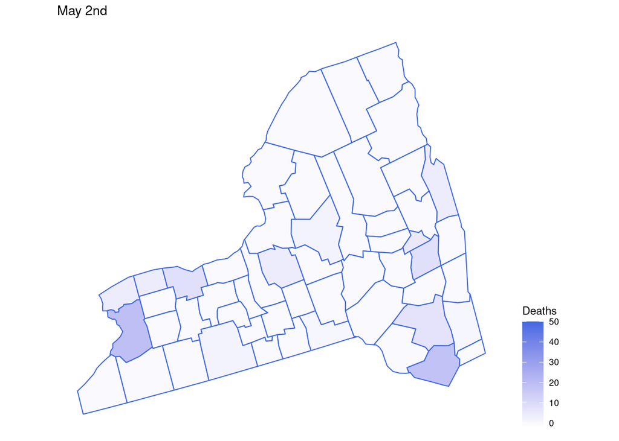

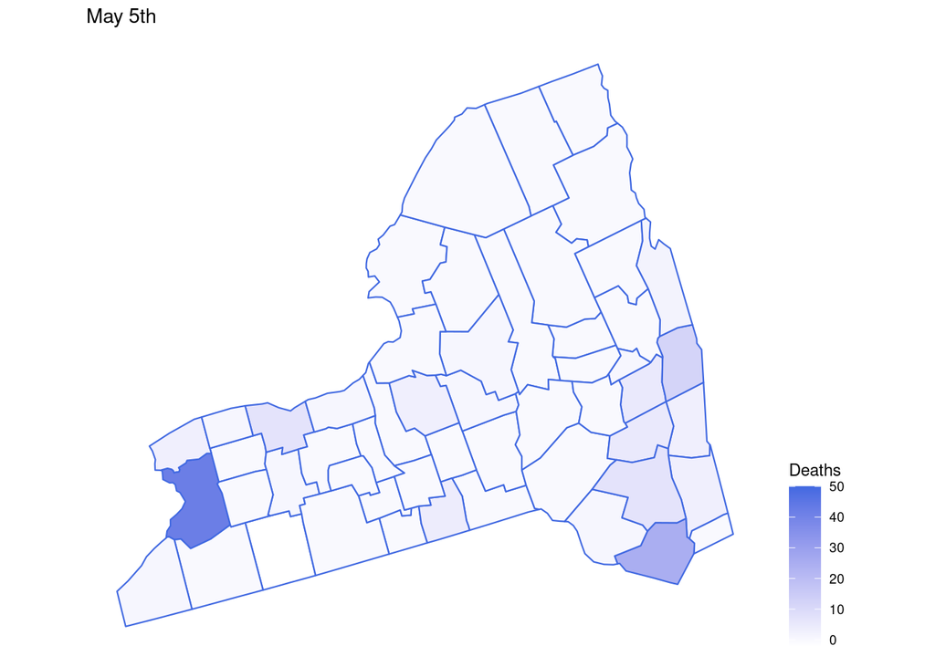

The following 5 graphs show the number of new deaths in the counties south of and including Weschester

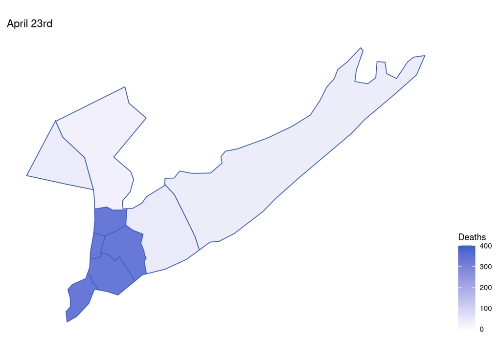

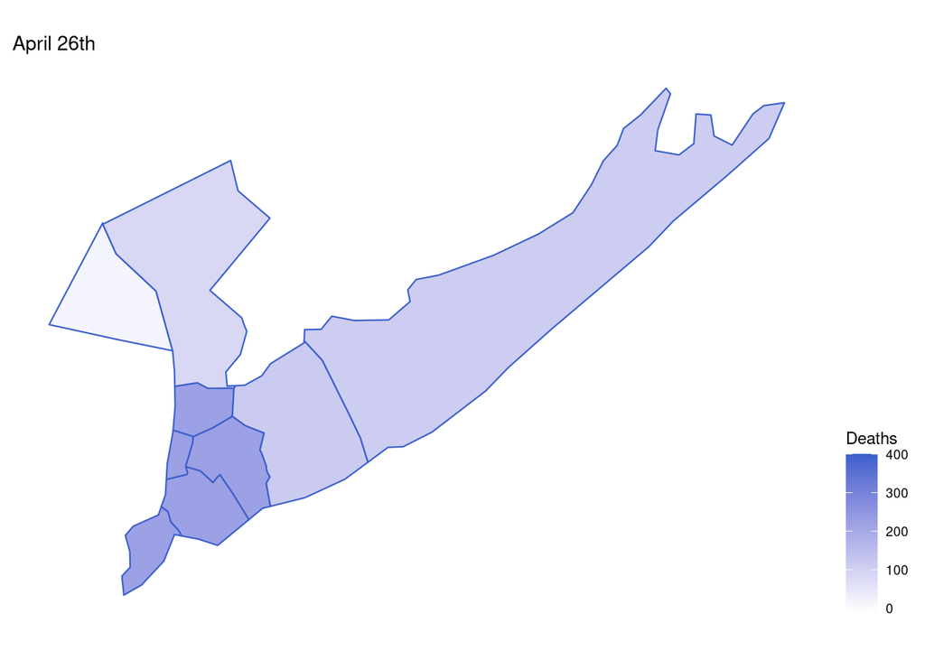

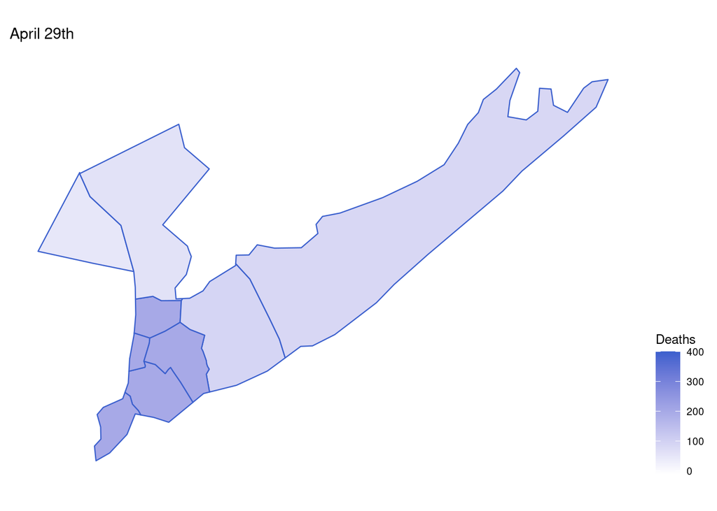

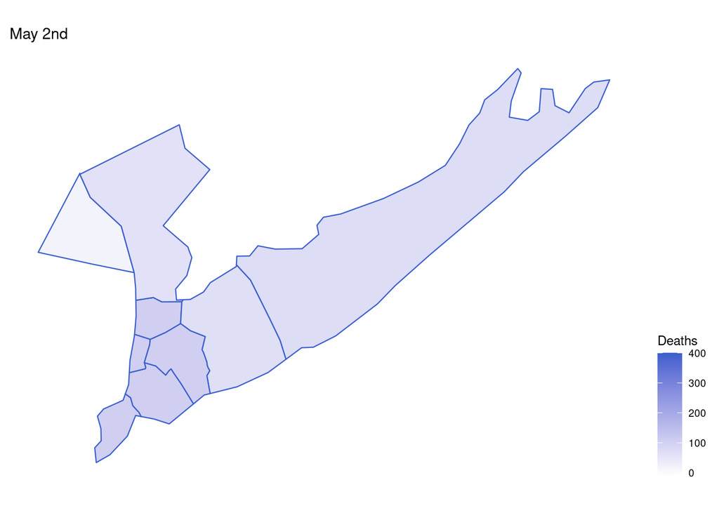

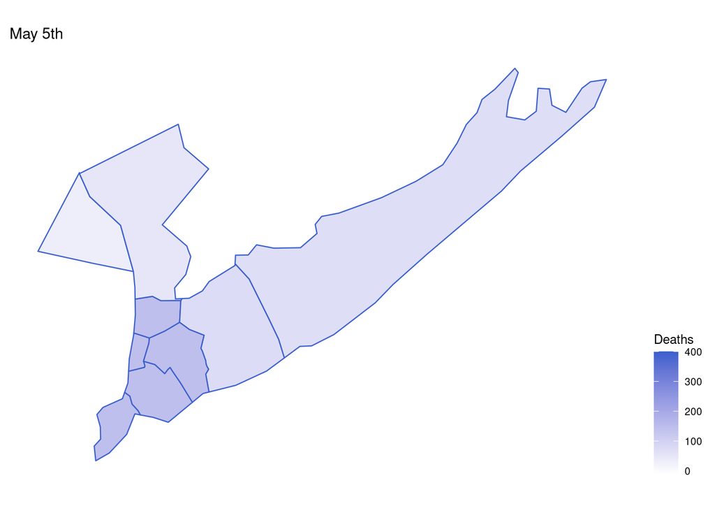

*Note: When extracting the county data from the overall country data, the 5 bouroughs of New York City were grouped together under one county. I needed to divide the number of deaths in New York City by 5 to be able to map the counties in the plot_usmap function*

### 4.1.3 Discussion

*These graphs show that the number of new deaths has decreased since New York was declared a hot zone. In terms of reopening, the decision should be to remain closed until number of new cases is small. The number of new deaths just shows how fatal the virus is. Until a vaccine is discovered, the number of deaths will always be greater than 0 because people who have the virus are not safe from it.*

*There are some strengths to these results. By mapping out each county in New York we can determine which counties are vunerable to fatalities and therefore pay more attention to slowing down the rate of infection. Clearly, the areas with high population densities are suffering the most, while the counties north of Westchester have little to no fatalities.*

*There are also some limitations to these results. The graphs do not account for population density, which could help explain the reason for such high numbers of deaths in the souther counties of New York. New York City has 20,000 people per square mile which would clearly lead to an increase in the number of cases and furthermore the number of deaths.*